# **Negation**

## Deep Learning - Final Project

### Buket Sak, Kascha Kruschwitz, Ludmila Bajuk

In this project, we developed a series of machine learning models to perform binary classification task on our text data. This project involves series of steps, from using GPT-Neo to fine-tuning BERT-based models and the custom models.

We first investigated the potential of Few-Shot learning, classifying text pairs to determine whether a given hypothesis is a negated version of a premise, by feeding the model with examples using the GPT-Neo model.

Next, we applied more robust and fine-tuned method using BERT-based classifier using "bert_base_en_uncased"(which is case-insensitive). While compling the model, as we have binary classification task, we used "binary crossentropy" as a loss function, "Adam" as an optimizer which adapts the learning rate for each parameter, "accuracy" as the evaluation metric. These metrics were tracked over multiple epochs to monitor the model’s performance.

Additionaly, we developed Model 2, a fully connected neural network that used the pooled embeddings from BERT as input, with multiple dense layers with ReLU activations.

Furhermore, Model 3 was an LSTM-based model that processed sequence embeddings from BERT.

We also used confusion matrices and visualizations to evaluate and compare models performance, to understand how each model handled the classification task. Laslty, we created a comprehensive table that displayed actual and predicted labels across all models for specific samples.

About the dataset: It focuses on negated textual pairs. It is taken from GitHub repository. Related link: https://github.com/dmlls/cannot-dataset/blob/main/README.md

```python
!pip install -q --upgrade keras-nlp
!pip install -q --upgrade keras

import numpy as np
import tensorflow as tf
import keras
import keras_nlp
import tensorflow_datasets as tfds
from tensorflow.keras.utils import to_categorical
import matplotlib.pyplot as plt
import torch
from tensorflow.keras import layers
from tensorflow.keras.models import Sequential
from IPython.display import display
import pandas as pd
import random
from statistics import mean
import matplotlib.pyplot as plt
from sklearn import metrics
from sklearn.metrics import accuracy_score, f1_score, classification_report, confusion_matrix
import time
import transformers
from transformers import AutoTokenizer, GPTNeoForCausalLM
```

[output not shown]

[output not shown]

```python
!pip3 freeze > requirements.txt
```

```python
#load from google drive
from google.colab import drive
drive.mount('/content/drive')

dataset = pd.read_csv('/content/drive/MyDrive/Colab Notebooks/cannot_dataset_v1.1.tsv', sep='\t')
```

```python
# load in kaggle
import pandas as pd

dataset = pd.read_csv('/kaggle/input/cannot-dataset/cannot_dataset_v1.1.tsv', sep='\t')
```

```python
# load in hulk server
import pandas as pd

dataset = pd.read_csv('cannot_dataset_v1.1.tsv', sep='\t')
```

## GPU settings

```python
# check if GPU
if torch.cuda.is_available(): #check if GPU is available
    device = torch.device("cuda:1") #set device, we need this later to push our model and the data to the GPU to perform computations
    print(f'There are {torch.cuda.device_count()} GPU(s) available.')
    print('Device name:', torch.cuda.get_device_name(0))

else:
    print('No GPU available, using the CPU instead.')
    device = torch.device("cpu")
```

```
There are 2 GPU(s) available.
Device name: Tesla T4
```

```python
# see what is happening
!nvidia-smi
```

```
Mon Aug 12 17:49:08 2024
+-----------------------------------------------------------------------------------------+
| NVIDIA-SMI 550.90.07              Driver Version: 550.90.07      CUDA Version: 12.4     |
|-----------------------------------------+------------------------+----------------------+
| GPU  Name                 Persistence-M | Bus-Id          Disp.A | Volatile Uncorr. ECC |
| Fan  Temp   Perf          Pwr:Usage/Cap |           Memory-Usage | GPU-Util  Compute M. |
|                                         |                        |               MIG M. |
|=========================================+========================+======================|
|   0  Tesla T4                       Off |   00000000:00:04.0 Off |                    0 |
| N/A   53C    P8              9W /   70W |       3MiB /  15360MiB |      0%      Default |
|                                         |                        |                  N/A |
+-----------------------------------------+------------------------+----------------------+
|   1  Tesla T4                       Off |   00000000:00:05.0 Off |                    0 |
| N/A   52C    P8             10W /   70W |       3MiB /  15360MiB |      0%      Default |
|                                         |                        |                  N/A |
+-----------------------------------------+------------------------+----------------------+

+-----------------------------------------------------------------------------------------+
| Processes:                                                                              |
|  GPU   GI   CI        PID   Type   Process name                              GPU Memory |
|        ID   ID                                                               Usage      |
|=========================================================================================|
|  No running processes found                                                             |
+-----------------------------------------------------------------------------------------+
```

```python
# select a specific GPU
selected_gpu = 0  # Change this to 0, 1, or 2 depending on which GPU you want to use

# Check if the specified GPU is available
if torch.cuda.is_available() and selected_gpu < torch.cuda.device_count():
    torch.cuda.set_device(selected_gpu)  # Set the selected GPU as the current device
    device = torch.device(f"cuda:{selected_gpu}")
    print(f'Using GPU {selected_gpu}.')
    print(f'There are {torch.cuda.device_count()} GPU(s) available.')
    for i in range(torch.cuda.device_count()):
        print(f'GPU {i} name:', torch.cuda.get_device_name(i))
    print('Current GPU:', torch.cuda.current_device())

else:
    print('No specified GPU available, using the CPU instead.')
    device = torch.device("cpu")
```

```
Using GPU 0.
There are 2 GPU(s) available.
GPU 0 name: Tesla T4
GPU 1 name: Tesla T4
Current GPU: 0
```

# Data Exploration and Preprocessing

## Exploration

```
Label 1: 39989 samples, which is 51.68% of the dataset.
Label 0: 37387 samples, which is 48.32% of the dataset.
```

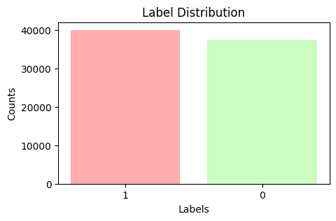

```python
# count labels to see if evenly distributed

lables = dataset["label"]

label_count = {}
for i in lables:
    i = str(i)
    if i in label_count:
        label_count[i] += 1
    else:
        label_count[i] = 1


total_samples = sum(label_count.values())

for label, count in label_count.items():
    percentage = (count / total_samples) * 100
    print(f"Label {label}: {count} samples, which is {percentage:.2f}% of the dataset.")

labels = list(label_count.keys())
counts = list(label_count.values())
plt.figure(figsize=(5, 3))

plt.bar(labels, counts, color=['#ffadad', '#caffbf'])
plt.xlabel('Labels')
plt.ylabel('Counts')
plt.title('Label Distribution')
plt.show()
```

Our labels are almost balanced with a slight difference towards label 1. Also, the dataset is fairly balanced giving roughly 51% and 48%.

Shuffle the data: To ensure that the data is randomly mixed before splitting it into training and testing sets.

```python
# shuffle rows of a df using a random seed - so that training and test data are in a random order, adopted from andrea
# Set a random seed for reproducibility
random_seed = 42
random.seed(random_seed)

# Shuffle the rows but keep original indices
dataset = dataset.sample(frac=1, random_state=random_seed)

# Initialize the DataFrame
df = pd.DataFrame(dataset)

# Print the summary first
print(f"{df.shape[0]} rows x {df.shape[1]} columns")
#Displaying the First 10 Rows
styled_df = dataset.head(10).style.set_properties(**{
    'text-align': 'left',
    'font-size': '12pt',
    'background-color': 'white'
})
styled_df
```

```
77376 rows x 3 columns
```

|  | premise | hypothesis | label |
| --- | --- | --- | --- |
| 26404 | In November 2011 European Court of Justice refused to confirm this opinion in a ruling. | In November 2011 European Court of Justice mainly confirmed this opinion in a ruling. | 1 |
| 7481 | The city is designated as a Million Plus Urban Agglomeration as per Government terminology. | The city is designated as an Under a Million Urban Agglomeration as per Government terminology. | 1 |
| 36957 | There are protections against discrimination based on sexual orientation. | Danish law includes protections against discrimination based on sexual orientation and gender identity/expression. | 0 |
| 52424 | But it can be declared deprecated : A coded character whose use is highly recommended. | But it can be declared deprecated : A coded character whose use is strongly discouraged. | 1 |
| 54858 | I'm not bad today. | I'm bad today. | 1 |
| 51856 | The magnetic moment of the antineutron is the opposite of that of the neutron. | The magnetic moment of the antineutron is the same as that of the neutron. | 1 |
| 53737 | Conferences and seminars were conducted by him. | He was also instrumental in conducting conferences and seminars. | 0 |
| 24145 | The only way the movie could be redeemed was as a comedy. | The only possible way this movie could be redeemed would be as MST3K fodder. | 0 |
| 53162 | Lastly, research continues in the other domains of the electromagnetic spectrum, including visible light. | Research continues in the other areas of the spectrum. | 0 |
| 62465 | The material's efficiency was partially reduced by the action of sea water. | The material's efficiency was increased by several times due to the action of sea water. | 1 |

Now, we take the specific row indices from the original DataFrame and determined where these rows end up after the DataFrame has been shuffled. We did this to ensure that the process is handled correctly.

```python
# Lists of Row Names from the Original Dataframe
antonym_row_names = [50487, 41715, 32427, 48323, 27068]
negation_row_names = [57658, 37518, 14465, 42008, 560]
paraphrased_row_names = [6543, 51922, 16802, 66953, 24641, 14896, 20770, 70327, 34157, 64309]

# Takes a list of row names  and
#returns a list of their new positions in the shuffled DataFrame
def get_df_index(row_names):
  index_list = []
  for i in row_names:
    index_list.append(dataset.index.get_loc(dataset.loc[i].name))
  return index_list

antonym_index = get_df_index(antonym_row_names)
negation_index = get_df_index(negation_row_names)
paraphrased_index = get_df_index(paraphrased_row_names)

# Print the results
print("Antonym Indices:")
print(f"{'Original':<15} {'Shuffled':<15}")
for original, new in zip(antonym_row_names, antonym_index):
    print(f"{original:<15} {new:<15}")

print("\nNegation Indices:")
print(f"{'Original':<15} {'Shuffled':<15}")
for original, new in zip(negation_row_names, negation_index):
    print(f"{original:<15} {new:<15}")

print("\nParaphrased Indices:")
print(f"{'Original':<15} {'Shuffled':<15}")
for original, new in zip(paraphrased_row_names, paraphrased_index):
    print(f"{original:<15} {new:<15}")
```

```
Antonym Indices:
Original        Shuffled
50487           2884
41715           52987
32427           71555
48323           11800
27068           44436

Negation Indices:
Original        Shuffled
57658           34924
37518           18576
14465           51686
42008           31695
560             69603

Paraphrased Indices:
Original        Shuffled
6543            10711
51922           7804
16802           54667
66953           32607
24641           52258
14896           22606
20770           2446
70327           33520
34157           76091
64309           75430
```

Then we analyzed distribution of token lengths for premise and hypothesis coloumns. The max sequence length we decided on in the preprocessing is 32, but this includes both sentences, so the max-length for an individual sentence will be 16.

```
Analysis of the 'premise' column:
Minimum length of sequences: 1
Maximum length of sequences: 58
Average length of sequences: 10.69
Number of sequences < 16 tokens: 72317
Percentage of sequences < 16 tokens: 93.46%
Number of sequences >= 16 tokens: 5059
Percentage of sequences >= 16 tokens: 6.54%


Analysis of the 'hypothesis' column:
Minimum length of sequences: 1
Maximum length of sequences: 58
Average length of sequences: 10.69
Number of sequences < 16 tokens: 72317
Percentage of sequences < 16 tokens: 93.46%
Number of sequences >= 16 tokens: 5059
Percentage of sequences >= 16 tokens: 6.54%
```

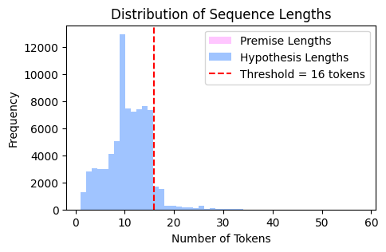

```python
# Define the max_len function - rough approximation because split by whitespace
def max_len(column):
    lent = [len(str(i).split(" ")) for i in dataset[column]]
    return min(lent), max(lent), np.mean(lent)

def analyze_sequence_lengths(dataset, column, threshold=16):
    # Using the max_len function to get the min, max, and average lengths
    min_len, max_len_val, avg_len = max_len(column)

    # Calculate the lengths of all sequences
    sequence_lengths = [len(str(i).split(" ")) for i in dataset[column]]

    # Count how many sequences are longer than or equal to the threshold
    longer_sequences = [length for length in sequence_lengths if length >= threshold]
    percentage_longer_sequences = (len(longer_sequences) / len(sequence_lengths)) * 100

    # Count how many sequences are shorter than to the threshold
    shorter_sequences = [length for length in sequence_lengths if length < threshold]
    percentage_shorter_sequences = (len(shorter_sequences) / len(sequence_lengths)) * 100

    # Print the results
    print(f"Analysis of the '{column}' column:")
    print(f"Minimum length of sequences: {min_len}")
    print(f"Maximum length of sequences: {max_len_val}")
    print(f"Average length of sequences: {avg_len:.2f}")
    print(f"Number of sequences < {threshold} tokens: {len(shorter_sequences)}")
    print(f"Percentage of sequences < {threshold} tokens: {percentage_shorter_sequences:.2f}%")
    print(f"Number of sequences >= {threshold} tokens: {len(longer_sequences)}")
    print(f"Percentage of sequences >= {threshold} tokens: {percentage_longer_sequences:.2f}%")
    print("\n")

    return sequence_lengths, len(longer_sequences), percentage_longer_sequences

# Analyzing the 'premise' and 'hypothesis' columns
premise_lengths, premise_longer_count, premise_longer_percentage = analyze_sequence_lengths(dataset, "premise")
hypothesis_lengths, hypothesis_longer_count, hypothesis_longer_percentage = analyze_sequence_lengths(dataset, "hypothesis")

plt.figure(figsize=(5, 3))

plt.hist(premise_lengths, bins=50, alpha=1, label='Premise Lengths', color="#ffc6ff")
plt.hist(hypothesis_lengths, bins=50, alpha=1, label='Hypothesis Lengths', color = "#a0c4ff")

plt.axvline(x=16, color='red', linestyle='--', label='Threshold = 16 tokens')

plt.title('Distribution of Sequence Lengths')
plt.xlabel('Number of Tokens')
plt.ylabel('Frequency')
plt.legend()
plt.show()
```

## Pre-processing

```python
# preparing text data for input into a BERT-based model by tokenizing and padding the sequences.
tokenizer = keras_nlp.models.BertTokenizer.from_preset(
    "bert_base_en_uncased")

# preprocessor includes tokenizer I believe and also padding
# round_robin removes data from beginning and end of sequences.
preprocessor = keras_nlp.models.BertPreprocessor.from_preset(
    "bert_base_en_uncased", sequence_length=32, truncate="round_robin")
```

[output not shown]

We prepared the data as pairs of sequences, which is the input format required for BERT.

```python
#input for masking task, sentence order task and the token's ids

first = tf.constant([dataset["premise"][i] for i in range(len(dataset))])
second = tf.constant([dataset["hypothesis"][i] for i in range(len(dataset))])
#passed through the BERT preprocessor and tokenizes the text, adds special tokens (e.g: [PAD],[CLS], [SEP]),
#pads the sequences to the specified length
preprocessed_data = preprocessor((first, second)) #sentence


# token_ids = preprocessed_data['token_ids'] #.to(device)
# padding_mask = preprocessed_data['padding_mask'] #.to(device)
# segment_ids = preprocessed_data['segment_ids']  #.to(device)

# check how the padding and special token insertion works
decoded_text = tokenizer.detokenize((preprocessed_data["token_ids"])[:8])
print("Decoded Text (First 8 Samples):")
for i, text in enumerate(decoded_text.numpy()):
    print(f"Sample {i+1}: {text.decode('utf-8')}\n")

#print(preprocessed_data)
```

```
Decoded Text (First 8 Samples):
Sample 1: [CLS] the joint typhoon warning center ( jtwc ) also issued warnings in an [SEP] the joint typhoon warning center ( jtwc ) only issued warnings in [SEP]

Sample 2: [CLS] commercial dnp is used as an antiseptic and as a non - [SEP] commercial dnp is unable to be utilized as an antiseptic or [SEP]

Sample 3: [CLS] spinal locks and cervical locks are allowed and mandatory in ibjjf brazilian [SEP] spinal locks and cervical locks are forbidden in ibjjf brazilian ji [SEP]

Sample 4: [CLS] dredgers excavate the sediment using mechanical or hydraulic methods or a combination of both [SEP] the dredgers use either mechanical or hydraulic methods . [SEP]

Sample 5: [CLS] in 2014 , nextgen earns klas top performance honors for ambula [SEP] in 2014 , nextgen fails to achieve klas top performance honors for [SEP]

Sample 6: [CLS] on june 22 , 2009 , the sec also filed civil fraud charges . [SEP] on june 22 , 2009 , the sec kept itself from filing civil fraud charges [SEP]

Sample 7: [CLS] each annex to a filed document must have page numbering . [SEP] each annex to a filed document is not required to have page numbering . [SEP] [PAD] [PAD] [PAD] [PAD]

Sample 8: [CLS] development of synchronous toothed - belts was begun by the gil [SEP] development of synchronous toothed - belts was halted by the [SEP]
```

Setting up data for the prediction task:

We combined the shuffled indices and original row names which are antonyms, negations, paraphrases into a single list for each.

```python
#combines the indices and row names from the three categories
pred_indices = antonym_index + negation_index + paraphrased_index
pred_rows = antonym_row_names + negation_row_names + paraphrased_row_names
#features that will be fed into the model for making predictions
pred_features = {
    "token_ids": tf.stack([preprocessed_data['token_ids'][i] for i in pred_indices]),
    "segment_ids": tf.stack([preprocessed_data['segment_ids'][i] for i in pred_indices]),
    "padding_mask": tf.stack([preprocessed_data['padding_mask'][i] for i in pred_indices]),
}

pred_labels = list(dataset.loc[[i for i in pred_rows], "label"])

# Print headers
print(f"{'Shuffled Index':<15} {'Original Row Name':<20} {'Label':<5}")

# Print each row's details
for shuffled_index, original_row, label in zip(pred_indices, pred_rows, pred_labels):
    print(f"{shuffled_index:<15} {original_row:<20} {label:<5}")
```

```
Shuffled Index  Original Row Name    Label
2884            50487                1
52987           41715                1
71555           32427                1
11800           48323                1
44436           27068                1
34924           57658                1
18576           37518                1
51686           14465                1
31695           42008                1
69603           560                  1
10711           6543                 0
7804            51922                0
54667           16802                0
32607           66953                0
52258           24641                0
22606           14896                0
2446            20770                0
33520           70327                0
76091           34157                0
75430           64309                0
```

```python
labels = list(dataset["label"])
print("Original Labels (from index 100 to 200):")
print(labels[100:200])

labels_01 = np.unique(np.array(labels), return_inverse=True)[1]
labels_01  = to_categorical(labels_01)

labels_02 = np.asarray(labels)
```

```
Original Labels (from index 100 to 200):
[0, 0, 1, 0, 1, 1, 1, 0, 0, 1, 0, 0, 1, 0, 1, 0, 0, 1, 0, 1, 0, 1, 0, 0, 0, 1, 0, 1, 1, 0, 1, 1, 0, 0, 1, 1, 0, 0, 0, 1, 1, 1, 1, 0, 1, 1, 0, 0, 1, 1, 1, 1, 0, 1, 0, 0, 0, 1, 0, 1, 0, 1, 1, 1, 0, 0, 1, 0, 0, 1, 0, 0, 0, 1, 0, 1, 1, 1, 1, 0, 0, 1, 1, 1, 0, 1, 0, 0, 0, 1, 1, 0, 0, 0, 0, 1, 1, 1, 1, 0]
```

We splitted the preprocessed data and their labels into training (85%) and testing (15%) sets, and created dictionaries for easy input.

```python
#calculates the number of samples to use for training by taking 85%.
training_samples = (len(labels) * 85)//100
#extract the training samples:
x_train_token_ids = preprocessed_data['token_ids'][:training_samples]
x_train_segment_ids = preprocessed_data["segment_ids"][:training_samples]
x_train_padding_mask = preprocessed_data["padding_mask"][:training_samples]

y_train_01 = labels_01[:training_samples]
y_train_02 = labels_02[:training_samples]

# extract the remaining samples
x_test_token_ids = preprocessed_data['token_ids'][training_samples:]
x_test_segment_ids = preprocessed_data["segment_ids"][training_samples:]
x_test_padding_mask = preprocessed_data["padding_mask"][training_samples:]

y_test_01 = labels_01[training_samples:]
y_test_02 = labels_02[training_samples:]

#print shapes
print(f"x_train_token_ids shape: {x_train_token_ids.shape}")
print("Shape of Model 1's label tensor:", y_train_01.shape)
print("Shape of Model 2's label tensor:", y_train_02.shape)

#creating feature dictionaries for Training and Testing
x_train_features = {
    "token_ids": x_train_token_ids,
    "segment_ids": x_train_segment_ids,
    "padding_mask": x_train_padding_mask,
}

x_test_features = {
     "token_ids": x_test_token_ids,
    "segment_ids": x_test_segment_ids,
    "padding_mask": x_test_padding_mask,
}

features = {
    "token_ids": preprocessed_data['token_ids'],
    "segment_ids": preprocessed_data["segment_ids"],
    "padding_mask": preprocessed_data["padding_mask"],
}
```

```
x_train_token_ids shape: (65769, 32)
Shape of Model 1's label tensor: (65769, 2)
Shape of Model 2's label tensor: (65769,)
```

# **FEW SHOT GPT-NEO**

Setting up a “Few-Shot” text generation:

```python
# Load the pre-trained GPT-Neo model and tokenizer
model_name = "EleutherAI/gpt-neo-1.3B"
tokenizer = AutoTokenizer.from_pretrained(model_name)
model = GPTNeoForCausalLM.from_pretrained(model_name)
```

We prepared a prompt that includes a series of labeled examples for the classification task.

```python
classification_examples = """
Classify the hypothesis as a negated (1) or non-negated (0) version of the premise. Examples:
Premise: This is a bad idea.
Hypothesis: This is not a good idea.
Label: 1
###
Premise: It's not healthy.
Hypothesis: It's unhealthy.
Label: 0
###
Premise: No one has a set of principles to live by.
Hypothesis: Everyone has a set of principles to live by.
Label: 1
###
Premise: The cat was sitting on the mat.
Hypothesis: The cat sat on the mat.
Label: 0
###
Premise:  I saw nothing at all.
Hypothesis: I didn't see anything.
Label: 0
###
Premise: Both do good jobs and are quite amusing.
Hypothesis: Both do good jobs and aren't quite amusing.
Label: 1
###
Premise: Griffon has been banned from being publicly traded since 1961.
Hypothesis: Griffon has been publicly traded since 1961.
Label: 1
###
Input: The plant will probably die if it hasn't had enough time to regenerate.
Hypothesis: If the plant has not had time to sufficiently regenerate it will probably perish.
Label: 0
###
Input: It's not uneasy to explain.
Hypothesis: It's not easy to explain.
Label: 1
###
Input: After retiring in 1954, Yee worked for a long time with Harrington.
Hypothesis: After retiring in 1954, Yee worked with Harrington nearly every day.
Label: 0
"""
```

We define a function that uses the model to classify and generate a response whether a given hypothesis is a negated (1) or non-negated (0) version of the premise.

```python
def classify_neg(classification_examples, premise, hypothesis):
    # prompt
    prompt = f"{classification_examples}\n\n{premise}\n\n{hypothesis}\n\n Label:"

    # Tokenize the prompt
    input_ids = tokenizer.encode(prompt, return_tensors="pt")

    # Generate text
    output = model.generate(
        input_ids,
        max_length=len(input_ids[0]) + 50,  # Increase length to allow for longer outputs
        num_return_sequences=1,
        temperature=0.7,
        pad_token_id=tokenizer.eos_token_id
    )

    # Decode the generated text
    generated_classification = tokenizer.decode(output[0], skip_special_tokens=True)

    # Extract the classification results
    start_idx = generated_classification.find("Label:") + len("Label:")
    end_idx = generated_classification.find("###", start_idx)
    if end_idx == -1:
        end_idx = None
    classification_result = generated_classification[start_idx:end_idx].strip()

    return classification_result
```

After classification, it stores the classification results in the [gpt_pred] list.

```python
premises = list(dataset.loc[[i for i in pred_rows], "premise"])
hypothesees = list(dataset.loc[[i for i in pred_rows], "hypothesis"])

#creating list to store the results
gpt_pred = []
for prem, hyp in zip(premises, hypothesees):
    answer = classify_neg(classification_examples, prem, hyp)
    gpt_pred.append(answer)

print(gpt_pred)
```

```
['1', '1', '1', '1', '1', '1', '1', '1', '1', '1', '1', '1', '1', '1', '1', '1', '1', '1', '1', '1']
```

Model predicted only 1(negated) for every input suggesting that the model could not distinguish between negated and non-negated sentences so it is biased to predict 1 for both classes.

We created a confusion matrix to evaluate the GPT-Neo model’s predictions.

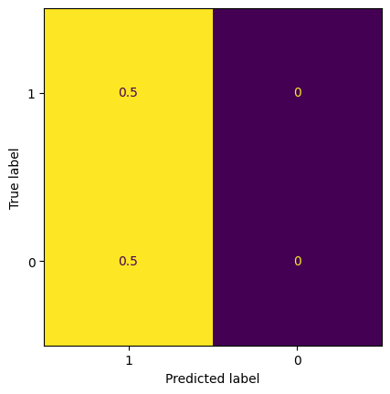

```python
#Create confusion matrix and normalizes it over predicted (columns)
result = confusion_matrix(pred_labels, [int(i) for i in gpt_pred], normalize='pred', labels=[1,0] )

# visualize confusion matrix with sklearn metrics
# define matrix and create labels
result_display = metrics.ConfusionMatrixDisplay(confusion_matrix = result, display_labels = ["1", "0"])

# display matrix
result_display.plot(colorbar=False)
plt.show()
```

The rows represent the true labels of the data, while columns represent the predicted labels by the model.

e.g: >

[TP, FP]

[FN, TN]

We have 0.5 for True positives and False negatives. It suggests that 50% of the instances that were actually 1 were correctly predicted as 1 by the model, while 50% of the instances that were actually 0 were incorrectly predicted as 1. As a result, all instances where the true label was 1 were predicted correctly, but all instances where the true label was 0 were incorrectly predicted as 1.

As a conclusion, we can say our model is better at predicting negated sentences compared to non-negated sentences, showing a significant issue with the model’s performance,as it fails to correctly identify any non-negated sentences.

# **MODEL 1**

Bert classifier

Setting up a BERT-based classifier model using a pre-defined preset. We set preprocessor to None because we already prepocessed the data:

```python
classifier = keras_nlp.models.BertClassifier.from_preset(
    "bert_base_en_uncased", preprocessor = None, #preprocessor = already preprocessed our data separately,,
    num_classes=2, load_weights=True,  trainable=True
    ) # .to(device)
```

[output not shown]

Compile the model:

-Binary crossentropy: We choose binary crossentropy because of the appropriateness for binary classification.

-Adam optimizer: is one of the most powerful optimizer especially in BERT. We preffered the Adam optimizer for our model because it effectively combines the benefits of adaptive learning rates and momentum as it adjusts the learning rate for each parameter and ensures efficient training.

```python
#Compile the model (add this before fitting)
classifier.compile(
    loss=tf.keras.losses.BinaryCrossentropy(from_logits=True),
    optimizer=tf.keras.optimizers.Adam(learning_rate=0.01), #learning_rate=0.001
    metrics=['accuracy']
)

# Training the BERT Classifier
history_01 = classifier.fit(
    x_train_features, y_train_01,
    epochs=5, batch_size=64, validation_split=0.2, verbose = 1
)
```

[output not shown]

```
823/823 ━━━━━━━━━━━━━━━━━━━━ 0s 433ms/step - accuracy: 0.5044 - loss: 0.7938
```

```
W0000 00:00:1723486037.615040     420 graph_launch.cc:671] Fallback to op-by-op mode because memset node breaks graph update
W0000 00:00:1723486041.963304     420 graph_launch.cc:671] Fallback to op-by-op mode because memset node breaks graph update
```

```
823/823 ━━━━━━━━━━━━━━━━━━━━ 491s 464ms/step - accuracy: 0.5044 - loss: 0.7937 - val_accuracy: 0.5176 - val_loss: 1.0540
```

```
W0000 00:00:1723486063.614780     422 graph_launch.cc:671] Fallback to op-by-op mode because memset node breaks graph update
```

```
823/823 ━━━━━━━━━━━━━━━━━━━━ 291s 354ms/step - accuracy: 0.5009 - loss: 0.7642 - val_accuracy: 0.5176 - val_loss: 1.0356
823/823 ━━━━━━━━━━━━━━━━━━━━ 291s 353ms/step - accuracy: 0.5006 - loss: 0.7619 - val_accuracy: 0.5176 - val_loss: 1.0069
823/823 ━━━━━━━━━━━━━━━━━━━━ 291s 353ms/step - accuracy: 0.4995 - loss: 0.7648 - val_accuracy: 0.5176 - val_loss: 1.0240
823/823 ━━━━━━━━━━━━━━━━━━━━ 291s 353ms/step - accuracy: 0.5007 - loss: 0.7620 - val_accuracy: 0.5176 - val_loss: 1.0319
```

**Evaluate Model 1**

```python
test_ev_01 = classifier.evaluate(x_test_features, y_test_01)
```

```
  4/363 ━━━━━━━━━━━━━━━━━━━━ 17s 49ms/step - accuracy: 0.5560 - loss: 0.9617
```

```
W0000 00:00:1723487267.505934     419 graph_launch.cc:671] Fallback to op-by-op mode because memset node breaks graph update
```

```
363/363 ━━━━━━━━━━━━━━━━━━━━ 23s 56ms/step - accuracy: 0.5170 - loss: 1.0331
```

```
W0000 00:00:1723487287.784287     420 graph_launch.cc:671] Fallback to op-by-op mode because memset node breaks graph update
```

**Plot Model 1**

```python
def plot_training_history(history, test_metrics):

    accuracy = history.history['accuracy']
    val_accuracy = history.history['val_accuracy']
    loss = history.history['loss']
    val_loss = history.history['val_loss']
    epochs_range = range(1, len(accuracy) + 1)

    # Plotting training & validation accuracy
    plt.figure(figsize=(14, 5))
    plt.subplot(1, 2, 1)
    plt.plot(epochs_range, accuracy, 'r', label='Training accuracy')
    plt.plot(epochs_range, val_accuracy, 'b', label='Validation accuracy')
    plt.plot(max(epochs_range), test_metrics[1], 'go', label='Test acc')
    plt.title('Training and validation accuracy')
    plt.xlabel('Epochs')
    plt.ylabel('Accuracy')
    plt.legend()

    # Plotting training & validation loss
    plt.subplot(1, 2, 2)
    plt.plot(epochs_range, loss, 'r', label='Training loss')
    plt.plot(epochs_range, val_loss, 'b', label='Validation loss')
    plt.plot(max(epochs_range), test_metrics[0], 'go', label='Test acc')
    plt.title('Training and validation loss')
    plt.xlabel('Epochs')
    plt.ylabel('Loss')
    plt.legend()

    plt.show()
```

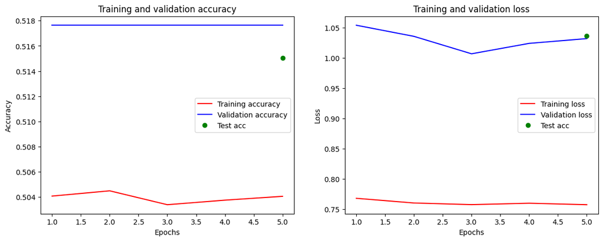

```python
plot_training_history(history_01, test_ev_01)
```

It appears that Model 1 is not learning from the training data at all. As we seen that accuracy lines are almost flat also indicates that the model' predictions are almost random (circa 0.5) in a binary classification task. Also, the fact that training and validation loss decrease very slightly over the epochs but they are really high indicates that the Model 1 is not minimizing the error effectively. In general, the model seems to be underfitting as it shows high bias for both training and test sets.

**Predictions for Model 1**

By using the BERT classifier to make predictions, then it applies the softmax function to convert these predictions into class probabilities.

```python
#We converted labels into a numpy array for easier manipulation
pred_predictions = classifier.predict(pred_features)
pred_labels_array = np.array(pred_labels)
print(pred_labels_array)

def softmax(x):
    return np.exp(x) / np.exp(x).sum(axis=0) #


# Get the class predictions with maximum probabilities
predictions1 = softmax(pred_predictions)

# Print the class predictions with maximum probabilities
predicted_classes1 = np.argmax(predictions1, axis=1)
print("Predicted labels:", predicted_classes1)
```

```
1/1 ━━━━━━━━━━━━━━━━━━━━ 4s 4s/step
[1 1 1 1 1 1 1 1 1 1 0 0 0 0 0 0 0 0 0 0]
Predicted labels: [0 0 0 0 0 0 0 0 0 0 0 0 0 0 0 0 0 0 0 0]
```

```
W0000 00:00:1723487667.990497     422 graph_launch.cc:671] Fallback to op-by-op mode because memset node breaks graph update
```

The model predicts 0(non-negated) for all samples regardless of the actual label. It appears that the model has a strong bias towards predicting the non-negated class.

**Classification report Model 1**

```python
# This code is taken from Andrea Ferreira.
def evaluate_classification(pred_labels, predicted_classes):

    # Calculating accuracy
    accuracy = accuracy_score(pred_labels, predicted_classes)

    # Calculating macro-F1 score
    macro_f1 = f1_score(pred_labels, predicted_classes, average='macro')

    # Generating a detailed classification report
    detailed_report = classification_report(pred_labels, predicted_classes)

    # Printing the results
    print(f"Accuracy: {accuracy:.4f}")
    print(f"Macro-F1 Score: {macro_f1:.4f}")
    print("Detailed Classification Report:")
    print(detailed_report)

    # Returning results as a dictionary
    return {
        'accuracy': accuracy,
        'macro_f1': macro_f1,
        'classification_report': detailed_report
    }
```

```python
evaluate_classification(pred_labels, predicted_classes1) #results1
```

```
Accuracy: 0.5000
Macro-F1 Score: 0.3333
Detailed Classification Report:
              precision    recall  f1-score   support

           0       0.50      1.00      0.67        10
           1       0.00      0.00      0.00        10

    accuracy                           0.50        20
   macro avg       0.25      0.50      0.33        20
weighted avg       0.25      0.50      0.33        20
```

```
{'accuracy': 0.5,
 'macro_f1': 0.3333333333333333,
 'classification_report': '              precision    recall  f1-score   support\n\n           0       0.50      1.00      0.67        10\n           1       0.00      0.00      0.00        10\n\n    accuracy                           0.50        20\n   macro avg       0.25      0.50      0.33      …
```

Accuracy is 0.5, so we can say that model is not performing well as its predictions are almost equivalent to random guessing. When we look at the recall, precision and F1-score being 0 for 1-negated class means that the model missed this class and failed to correctly identift any of its instances. In general, this imbalance suggests significant issues in the model’s ability to generalize across both classes.

**Confusion** **matrix** **Model 1**

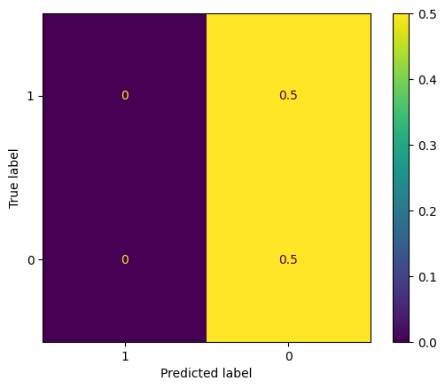

```python
#Create confusion matrix and normalizes it over predicted (columns)
result1 = confusion_matrix(pred_labels_array, predicted_classes1, normalize='pred', labels=[1,0] )

# visualize confusion matrix with sklearn metrics
# define matrix and create labels
result_display1 = metrics.ConfusionMatrixDisplay(confusion_matrix = result1, display_labels = ["1", "0"])

# display matrix
result_display1.plot() #colorbar=True
plt.show()
```

The representation is the same with Few-Shot:

e.g: >

[TP, FP]

[FN, TN]

Confusion matrix we see confirms the comments I made for this model.

TP = 0 means not correctly predicting any instances of the 1-negated class.

TN = 0.5 means 50% of the instances that were actually 0 (non-negated class) were correctly predicted.

FP = 0 means the model did not incorrectly predict any 0 instances as 1.

Again, it is seen that the Bert model is biased towards predicting the negative class 0.

# **MODEL 2**

Embedding and Classifier

The embedder creates 2 types of embeddings:

- pooled embeddings:
  - representation of the entire sequence (both sentences) as a single vector
  - input for the model with only dense layers
- sequence embeddings:
  - vector for each token in the sequence
  - suitable as input for the LSTM, as it takes word order into account

```python
# Initialize the BERT backbone model with pre-trained weights
with tf.device('/device:GPU:0'):
    embedder = keras_nlp.models.BertBackbone.from_preset(
        "bert_base_en_uncased",  load_weights=True, preprocessor=None, trainable=False
    )
```

[output not shown]

```python
# Record the start time for measuring
start_time = time.time()

batch_size = 32
# Initialize lists to store the seq-level and pooled embeddings
seq_embeddings = []
pool_embeddings = []
# Process the input data in batches
with tf.device('/device:GPU:0'):
    for i in range(0, len(features["token_ids"]), batch_size):
        # Slice the features
        batch_features = {
            "token_ids": features["token_ids"][i: i + batch_size],
            "segment_ids": features["segment_ids"][i: i + batch_size],
            "padding_mask": features["padding_mask"][i: i + batch_size],
        }
        batch_embeddings = embedder(batch_features)
        # Store the sequence-level embeddings (for each token)
        seq_embeddings.extend(batch_embeddings['sequence_output'])
        # Store the pooled embeddings (for the whole sequence)
        pool_embeddings.extend(batch_embeddings['pooled_output'])

# Record the end time
end_time = time.time()

# Calculate and print the elapsed time
elapsed_time = end_time - start_time
print(f"Elapsed time: {elapsed_time:.2f} seconds")
```

```
Elapsed time: 523.35 seconds
```

```python
print("Number of Sequence Embeddings:", len(seq_embeddings))
#print(seq_embeddings.shape)
print("Length of y_train_02:", len(y_train_02))
print("Number of Token IDs in Features:", len(features["token_ids"]))
print("\nSample of Token IDs (first 2):")
print(features["token_ids"][:2])
print("\nSample Data (first 2 sequences):")
print(seq_embeddings[:2])
```

```
Number of Sequence Embeddings: 77376
Length of y_train_02: 65769
Number of Token IDs in Features: 77376

Sample of Token IDs (first 2):
tf.Tensor(
[[  101  1996  4101 15393  5432  2415  1006  1046  2102 16526  1007  2036
   3843 16234  1999  2019   102  1996  4101 15393  5432  2415  1006  1046
   2102 16526  1007  2069  3843 16234  1999   102]
 [  101  3293  1040 16275  2003  2109  2004  2019  3424  3366 20746  1998
   2004  1037  2512  1011   102  3293  1040 16275  2003  4039  2000  2022
  12550  2004  2019  3424  3366 20746  2030   102]], shape=(2, 32), dtype=int32)

Sample Data (first 2 sequences):
[<tf.Tensor: shape=(32, 768), dtype=float32, numpy=
array([[-0.9500362 , -0.02559358, -0.42308766, ..., -0.8528032 ,
         0.09129428,  0.07362685],
       [-0.06119687, -0.11673031, -0.4369478 , ...,  0.09962112,
         1.2962011 ,  0.13774018],
       [ 0.16016704, -0.19487922,  0.3218239 , ..., -0.12377342,
         0.19195   , -0.5271513 ],
       ...,
       [-0.01281314,  0.40843508,  0.6968195 , ..., -0.87715006,
        -0.7999142 , -0.61531425],
       [-2.1548383 , -0.7931634 ,  0.03971399, ..., -0.451414  ,
         0.21314639, -0.09525715],
       [ 0.55590075, -0.39198613, -0.16347201, ..., -0.19363664,
        -0.57400143,  0.07770665]], dtype=float32)>, <tf.Tensor: shape=(32, 768), dtype=float32, numpy=
array([[-1.0062566 ,  0.38287914, -0.64008546, ..., -1.0775943 ,
         0.36903223,  0.5415491 ],
       [ 0.34522346, -0.1650456 , -0.9361593 , ..., -0.58704406,
         1.1182756 ,  0.2008976 ],
       [ 0.37036705, -0.776815  , -0.74837345, ..., -0.68861127,
         0.60220605,  0.34566006],
       ...,
       [-0.3521036 ,  0.01505687, -0.43319905, ..., -0.6747757 ,
        -0.5306159 , -0.34988332],
       [-0.3371425 ,  0.20955034, -0.4774155 , ..., -0.26456767,
         0.26360524,  0.26977938],
       [ 0.76028746,  0.284342  , -0.57232475, ..., -0.11799466,
        -0.35812798,  0.03463599]], dtype=float32)>]
```

We reshaped and splitted pooled and sequence embeddings into training and testing sets then we converted the lists of embeddings into tensors to work with TenserFlow models.

! I had to use only the part of the dataset for this model because it gives me an error indicating that my GPU ran out of memory. I do not know the reason of it so maybe it is a bug in kaggle or this could be also due to the large size of the data or the complexity of the model(?).

```python
#Reshapes the pooled embeddings into a 2D tensor with shape representing an entire sequence

reshaped_pool_embeddings = tf.reshape(pool_embeddings, shape=(-1, 768))
#then splits it into training and testing sets
x_train_02 = reshaped_pool_embeddings[:training_samples]
x_test_02 = reshaped_pool_embeddings[training_samples:]

#splits the the sequence embeddings into training and testing sets
x_train_03 = seq_embeddings[:training_samples]
x_test_03 = seq_embeddings[training_samples:]

#65769 is full amount, but GPU runs out of memory if using full lenght
# thus increase if possible, but reduce if necessary (30000 ideally, anything lower is not super good)
train_03_len = 40000

with tf.device('/device:GPU:1'):
    #x_train_03 = tf.stack(x_train_03)  # full set
    x_train_03 = tf.stack(x_train_03[:train_03_len]) #can be limitted the size of x_train_03, if memory issues arise.
    x_test_03 = tf.stack(x_test_03)

print(x_train_03.get_shape())


#y_train_03 = y_train_02  # full set
y_train_03 = y_train_02[:train_03_len] #can be limitted the size of y_train_02, if memory issues arise.
y_test_03 = y_test_02

# for making predictions with Model 2
x_pred_02 = tf.gather(reshaped_pool_embeddings,
                indices=pred_indices)

x_pred_03 = [seq_embeddings[x] for x in pred_indices]

x_pred_03 = tf.stack(x_pred_03)
```

```
(40000, 32, 768)
```

### Model 2

We initilized a sequential model in Keras. We preffered "sigmoid" activation layer as final layer because of the type of classification task.

```python
model_02 = Sequential(name='Model_02')
model_02.add(layers.Dense(256, activation='relu', input_shape=(768,)))
model_02.add(layers.Dense(256, activation='relu'))
model_02.add(layers.Dense(128, activation='relu'))
model_02.add(layers.Dense(64, activation='relu'))
model_02.add(layers.Dense(16, activation='relu'))
model_02.add(layers.Dense(1, activation='sigmoid')) #used for binary classficaiton

model_02.compile(optimizer='adam', loss='binary_crossentropy', metrics=['accuracy'])
model_02.summary()

#Train the model

history_02 = model_02.fit(x_train_02, y_train_02,
                            epochs=50,
                            batch_size=32,
                            validation_split=0.1)
```

```
Model: "Model_02"
```

```
┏━━━━━━━━━━━━━━━━━━━━━━━━━━━━━━━━━┳━━━━━━━━━━━━━━━━━━━━━━━━┳━━━━━━━━━━━━━━━┓
┃ Layer (type)                    ┃ Output Shape           ┃       Param # ┃
┡━━━━━━━━━━━━━━━━━━━━━━━━━━━━━━━━━╇━━━━━━━━━━━━━━━━━━━━━━━━╇━━━━━━━━━━━━━━━┩
│ dense (Dense)                   │ (None, 256)            │       196,864 │
├─────────────────────────────────┼────────────────────────┼───────────────┤
│ dense_1 (Dense)                 │ (None, 256)            │        65,792 │
├─────────────────────────────────┼────────────────────────┼───────────────┤
│ dense_2 (Dense)                 │ (None, 128)            │        32,896 │
├─────────────────────────────────┼────────────────────────┼───────────────┤
│ dense_3 (Dense)                 │ (None, 64)             │         8,256 │
├─────────────────────────────────┼────────────────────────┼───────────────┤
│ dense_4 (Dense)                 │ (None, 16)             │         1,040 │
├─────────────────────────────────┼────────────────────────┼───────────────┤
│ dense_5 (Dense)                 │ (None, 1)              │            17 │
└─────────────────────────────────┴────────────────────────┴───────────────┘
```

```
 Total params: 304,865 (1.16 MB)
```

```
 Trainable params: 304,865 (1.16 MB)
```

```
 Non-trainable params: 0 (0.00 B)
```

```
  84/1850 ━━━━━━━━━━━━━━━━━━━━ 3s 2ms/step - accuracy: 0.5395 - loss: 0.6998
```

```
W0000 00:00:1723489806.870040     420 graph_launch.cc:671] Fallback to op-by-op mode because memset node breaks graph update
```

```
1850/1850 ━━━━━━━━━━━━━━━━━━━━ 0s 3ms/step - accuracy: 0.5155 - loss: 0.6949
```

```
W0000 00:00:1723489811.701446     422 graph_launch.cc:671] Fallback to op-by-op mode because memset node breaks graph update
W0000 00:00:1723489812.151524     421 graph_launch.cc:671] Fallback to op-by-op mode because memset node breaks graph update
```

```
1850/1850 ━━━━━━━━━━━━━━━━━━━━ 9s 3ms/step - accuracy: 0.5155 - loss: 0.6949 - val_accuracy: 0.5170 - val_loss: 0.6926
  81/1850 ━━━━━━━━━━━━━━━━━━━━ 3s 2ms/step - accuracy: 0.5228 - loss: 0.6922
```

```
W0000 00:00:1723489812.745396     421 graph_launch.cc:671] Fallback to op-by-op mode because memset node breaks graph update
```

```
1850/1850 ━━━━━━━━━━━━━━━━━━━━ 4s 2ms/step - accuracy: 0.5192 - loss: 0.6925 - val_accuracy: 0.4843 - val_loss: 0.6944
1850/1850 ━━━━━━━━━━━━━━━━━━━━ 4s 2ms/step - accuracy: 0.5158 - loss: 0.6929 - val_accuracy: 0.5170 - val_loss: 0.6926
1850/1850 ━━━━━━━━━━━━━━━━━━━━ 4s 2ms/step - accuracy: 0.5142 - loss: 0.6929 - val_accuracy: 0.5170 - val_loss: 0.6926
1850/1850 ━━━━━━━━━━━━━━━━━━━━ 4s 2ms/step - accuracy: 0.5134 - loss: 0.6928 - val_accuracy: 0.5170 - val_loss: 0.6926
1850/1850 ━━━━━━━━━━━━━━━━━━━━ 4s 2ms/step - accuracy: 0.5198 - loss: 0.6924 - val_accuracy: 0.5170 - val_loss: 0.6926
1850/1850 ━━━━━━━━━━━━━━━━━━━━ 4s 2ms/step - accuracy: 0.5185 - loss: 0.6927 - val_accuracy: 0.5170 - val_loss: 0.6926
1850/1850 ━━━━━━━━━━━━━━━━━━━━ 4s 2ms/step - accuracy: 0.5141 - loss: 0.6928 - val_accuracy: 0.5170 - val_loss: 0.6926
1850/1850 ━━━━━━━━━━━━━━━━━━━━ 4s 2ms/step - accuracy: 0.5204 - loss: 0.6923 - val_accuracy: 0.5170 - val_loss: 0.6926
1850/1850 ━━━━━━━━━━━━━━━━━━━━ 4s 2ms/step - accuracy: 0.5150 - loss: 0.6927 - val_accuracy: 0.5170 - val_loss: 0.6926
1850/1850 ━━━━━━━━━━━━━━━━━━━━ 4s 2ms/step - accuracy: 0.5144 - loss: 0.6929 - val_accuracy: 0.5170 - val_loss: 0.6926
1850/1850 ━━━━━━━━━━━━━━━━━━━━ 4s 2ms/step - accuracy: 0.5191 - loss: 0.6924 - val_accuracy: 0.5170 - val_loss: 0.6926
1850/1850 ━━━━━━━━━━━━━━━━━━━━ 4s 2ms/step - accuracy: 0.5179 - loss: 0.6925 - val_accuracy: 0.5170 - val_loss: 0.6926
1850/1850 ━━━━━━━━━━━━━━━━━━━━ 4s 2ms/step - accuracy: 0.5135 - loss: 0.6928 - val_accuracy: 0.5170 - val_loss: 0.6926
1850/1850 ━━━━━━━━━━━━━━━━━━━━ 4s 2ms/step - accuracy: 0.5151 - loss: 0.6928 - val_accuracy: 0.5170 - val_loss: 0.6926
1850/1850 ━━━━━━━━━━━━━━━━━━━━ 4s 2ms/step - accuracy: 0.5188 - loss: 0.6925 - val_accuracy: 0.5170 - val_loss: 0.6926
1850/1850 ━━━━━━━━━━━━━━━━━━━━ 4s 2ms/step - accuracy: 0.5149 - loss: 0.6927 - val_accuracy: 0.5170 - val_loss: 0.6926
1850/1850 ━━━━━━━━━━━━━━━━━━━━ 4s 2ms/step - accuracy: 0.5192 - loss: 0.6924 - val_accuracy: 0.5170 - val_loss: 0.6926
1850/1850 ━━━━━━━━━━━━━━━━━━━━ 4s 2ms/step - accuracy: 0.5126 - loss: 0.6929 - val_accuracy: 0.5170 - val_loss: 0.6926
1850/1850 ━━━━━━━━━━━━━━━━━━━━ 4s 2ms/step - accuracy: 0.5171 - loss: 0.6926 - val_accuracy: 0.5170 - val_loss: 0.6926
1850/1850 ━━━━━━━━━━━━━━━━━━━━ 4s 2ms/step - accuracy: 0.5190 - loss: 0.6925 - val_accuracy: 0.5170 - val_loss: 0.6926
1850/1850 ━━━━━━━━━━━━━━━━━━━━ 4s 2ms/step - accuracy: 0.5203 - loss: 0.6924 - val_accuracy: 0.5170 - val_loss: 0.6926
1850/1850 ━━━━━━━━━━━━━━━━━━━━ 4s 2ms/step - accuracy: 0.5167 - loss: 0.6926 - val_accuracy: 0.5170 - val_loss: 0.6926
1850/1850 ━━━━━━━━━━━━━━━━━━━━ 4s 2ms/step - accuracy: 0.5137 - loss: 0.6928 - val_accuracy: 0.5170 - val_loss: 0.6926
1850/1850 ━━━━━━━━━━━━━━━━━━━━ 4s 2ms/step - accuracy: 0.5194 - loss: 0.6924 - val_accuracy: 0.5170 - val_loss: 0.6926
1850/1850 ━━━━━━━━━━━━━━━━━━━━ 4s 2ms/step - accuracy: 0.5174 - loss: 0.6926 - val_accuracy: 0.5170 - val_loss: 0.6926
1850/1850 ━━━━━━━━━━━━━━━━━━━━ 4s 2ms/step - accuracy: 0.5169 - loss: 0.6926 - val_accuracy: 0.5170 - val_loss: 0.6926
1850/1850 ━━━━━━━━━━━━━━━━━━━━ 4s 2ms/step - accuracy: 0.5125 - loss: 0.6929 - val_accuracy: 0.5170 - val_loss: 0.6926
1850/1850 ━━━━━━━━━━━━━━━━━━━━ 4s 2ms/step - accuracy: 0.5190 - loss: 0.6925 - val_accuracy: 0.5170 - val_loss: 0.6926
1850/1850 ━━━━━━━━━━━━━━━━━━━━ 4s 2ms/step - accuracy: 0.5192 - loss: 0.6924 - val_accuracy: 0.5170 - val_loss: 0.6926
1850/1850 ━━━━━━━━━━━━━━━━━━━━ 4s 2ms/step - accuracy: 0.5178 - loss: 0.6925 - val_accuracy: 0.5170 - val_loss: 0.6926
1850/1850 ━━━━━━━━━━━━━━━━━━━━ 4s 2ms/step - accuracy: 0.5146 - loss: 0.6928 - val_accuracy: 0.5170 - val_loss: 0.6927
1850/1850 ━━━━━━━━━━━━━━━━━━━━ 4s 2ms/step - accuracy: 0.5181 - loss: 0.6925 - val_accuracy: 0.5170 - val_loss: 0.6926
1850/1850 ━━━━━━━━━━━━━━━━━━━━ 4s 2ms/step - accuracy: 0.5166 - loss: 0.6926 - val_accuracy: 0.5170 - val_loss: 0.6926
1850/1850 ━━━━━━━━━━━━━━━━━━━━ 4s 2ms/step - accuracy: 0.5145 - loss: 0.6928 - val_accuracy: 0.5170 - val_loss: 0.6926
1850/1850 ━━━━━━━━━━━━━━━━━━━━ 4s 2ms/step - accuracy: 0.5182 - loss: 0.6925 - val_accuracy: 0.5170 - val_loss: 0.6926
1850/1850 ━━━━━━━━━━━━━━━━━━━━ 4s 2ms/step - accuracy: 0.5195 - loss: 0.6924 - val_accuracy: 0.5170 - val_loss: 0.6926
1850/1850 ━━━━━━━━━━━━━━━━━━━━ 4s 2ms/step - accuracy: 0.5163 - loss: 0.6926 - val_accuracy: 0.5170 - val_loss: 0.6926
1850/1850 ━━━━━━━━━━━━━━━━━━━━ 4s 2ms/step - accuracy: 0.5165 - loss: 0.6926 - val_accuracy: 0.5170 - val_loss: 0.6926
1850/1850 ━━━━━━━━━━━━━━━━━━━━ 4s 2ms/step - accuracy: 0.5156 - loss: 0.6927 - val_accuracy: 0.5170 - val_loss: 0.6926
1850/1850 ━━━━━━━━━━━━━━━━━━━━ 4s 2ms/step - accuracy: 0.5177 - loss: 0.6925 - val_accuracy: 0.5170 - val_loss: 0.6926
1850/1850 ━━━━━━━━━━━━━━━━━━━━ 4s 2ms/step - accuracy: 0.5209 - loss: 0.6923 - val_accuracy: 0.5170 - val_loss: 0.6926
1850/1850 ━━━━━━━━━━━━━━━━━━━━ 4s 2ms/step - accuracy: 0.5136 - loss: 0.6928 - val_accuracy: 0.5170 - val_loss: 0.6927
1850/1850 ━━━━━━━━━━━━━━━━━━━━ 4s 2ms/step - accuracy: 0.5163 - loss: 0.6927 - val_accuracy: 0.5170 - val_loss: 0.6926
1850/1850 ━━━━━━━━━━━━━━━━━━━━ 4s 2ms/step - accuracy: 0.5198 - loss: 0.6924 - val_accuracy: 0.5170 - val_loss: 0.6926
1850/1850 ━━━━━━━━━━━━━━━━━━━━ 4s 2ms/step - accuracy: 0.5185 - loss: 0.6925 - val_accuracy: 0.5170 - val_loss: 0.6926
1850/1850 ━━━━━━━━━━━━━━━━━━━━ 4s 2ms/step - accuracy: 0.5172 - loss: 0.6926 - val_accuracy: 0.5170 - val_loss: 0.6926
1850/1850 ━━━━━━━━━━━━━━━━━━━━ 4s 2ms/step - accuracy: 0.5186 - loss: 0.6925 - val_accuracy: 0.5170 - val_loss: 0.6926
1850/1850 ━━━━━━━━━━━━━━━━━━━━ 4s 2ms/step - accuracy: 0.5186 - loss: 0.6925 - val_accuracy: 0.5170 - val_loss: 0.6926
1850/1850 ━━━━━━━━━━━━━━━━━━━━ 4s 2ms/step - accuracy: 0.5188 - loss: 0.6925 - val_accuracy: 0.5170 - val_loss: 0.6926
```

```python
test_ev_02 = model_02.evaluate(x_test_02, y_test_02)
```

```
363/363 ━━━━━━━━━━━━━━━━━━━━ 1s 3ms/step - accuracy: 0.5170 - loss: 0.6926
```

```
W0000 00:00:1723490351.731840     419 graph_launch.cc:671] Fallback to op-by-op mode because memset node breaks graph update
```

**Plot Model 2**

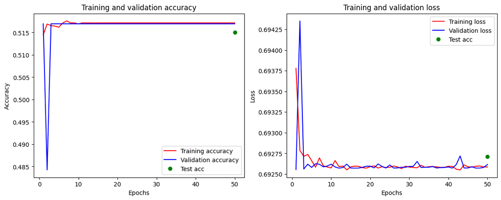

```python
plot_training_history(history_02, test_ev_02)
```

**Predictions for Model 2**

```python
pred_predictions2 = model_02.predict(x_pred_02)
pred_labels_array = np.array(pred_labels)
print(pred_labels_array)

print(pred_predictions)

#We set a threshold of 0.5 to assign a class label based on it.
#If the probability is greater than or equal to 0.5, the model predicts 1.
#Else = 0
predicted_classes2 = [1 if prob[0] >= 0.5 else 0 for prob in pred_predictions2]
predicted_classes2_array = np.array(predicted_classes2)

print(predicted_classes2_array)
```

```
1/1 ━━━━━━━━━━━━━━━━━━━━ 0s 419ms/step
[1 1 1 1 1 1 1 1 1 1 0 0 0 0 0 0 0 0 0 0]
[[-1.831047   1.8313272]
 [-1.831047   1.8313272]
 [-1.831047   1.8313272]
 [-1.831047   1.8313272]
 [-1.831047   1.8313272]
 [-1.831047   1.8313272]
 [-1.831047   1.8313272]
 [-1.831047   1.8313272]
 [-1.831047   1.8313272]
 [-1.831047   1.8313272]
 [-1.831047   1.8313272]
 [-1.831047   1.8313272]
 [-1.831047   1.8313272]
 [-1.831047   1.8313272]
 [-1.831047   1.8313272]
 [-1.831047   1.8313272]
 [-1.831047   1.8313272]
 [-1.831047   1.8313272]
 [-1.831047   1.8313272]
 [-1.831047   1.8313272]]
[1 1 1 1 1 1 1 1 1 1 1 1 1 1 1 1 1 1 1 1]
```

```
W0000 00:00:1723490391.365332     421 graph_launch.cc:671] Fallback to op-by-op mode because memset node breaks graph update
```

Model 2 consistently predicts only 1 (as negated) for all true labels. We can truly say that Model 2 does not distiguish between different inputs.

**Classification report Model 2**

```python
evaluate_classification(pred_labels, predicted_classes2) #results2 =
```

```
Accuracy: 0.5000
Macro-F1 Score: 0.3333
Detailed Classification Report:
              precision    recall  f1-score   support

           0       0.00      0.00      0.00        10
           1       0.50      1.00      0.67        10

    accuracy                           0.50        20
   macro avg       0.25      0.50      0.33        20
weighted avg       0.25      0.50      0.33        20
```

```
{'accuracy': 0.5,
 'macro_f1': 0.3333333333333333,
 'classification_report': '              precision    recall  f1-score   support\n\n           0       0.00      0.00      0.00        10\n           1       0.50      1.00      0.67        10\n\n    accuracy                           0.50        20\n   macro avg       0.25      0.50      0.33      …
```

The classification report for Model 2 is nearly identical to that of Model 1, with the main difference being a bias towards predicting class 1. An accuracy of 0.5 accuracy is not a good accuracy for a binary classificaiton task. The low F1-score indicates poor performance, basically this model is no better than Model 1.

**Confusion** **matrix** **Model 2**

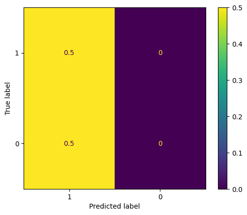

```python
#Create confusion matrix and normalizes it over predicted (columns)
result2 = confusion_matrix(pred_labels_array, predicted_classes2 , normalize='pred', labels=[1,0] )

# visualize confusion matrix with sklearn metrics
# define matrix and create labels
result_display2 = metrics.ConfusionMatrixDisplay(confusion_matrix = result2, display_labels = ["1", "0"])

# display matrix
result_display2.plot()
plt.show()
```

Confusion matrix: It is the same as Model 1 except the tendency of predicting 1 (negated) than 0(non-negated).

e.g: >

[TP, FP]

[FN, TN]

### Model 3

We created a sequential neural network with 1 LSTM layer followed by dense layers.

```python
model_03 = Sequential(name='Model_03')

model_03.add(layers.LSTM(128, input_shape=(32, 768)))  # Add LSTM layer with 64 units, input = (seq_length, vector_size)
model_03.add(layers.Dense(32, activation='relu'))
model_03.add(layers.Dense(1, activation='sigmoid'))

model_03.compile(optimizer='adam', loss='binary_crossentropy', metrics=['accuracy'])
model_03.summary()
```

```
Model: "Model_03"
```

```
┏━━━━━━━━━━━━━━━━━━━━━━━━━━━━━━━━━┳━━━━━━━━━━━━━━━━━━━━━━━━┳━━━━━━━━━━━━━━━┓
┃ Layer (type)                    ┃ Output Shape           ┃       Param # ┃
┡━━━━━━━━━━━━━━━━━━━━━━━━━━━━━━━━━╇━━━━━━━━━━━━━━━━━━━━━━━━╇━━━━━━━━━━━━━━━┩
│ lstm (LSTM)                     │ (None, 128)            │       459,264 │
├─────────────────────────────────┼────────────────────────┼───────────────┤
│ dense_6 (Dense)                 │ (None, 32)             │         4,128 │
├─────────────────────────────────┼────────────────────────┼───────────────┤
│ dense_7 (Dense)                 │ (None, 1)              │            33 │
└─────────────────────────────────┴────────────────────────┴───────────────┘
```

```
 Total params: 463,425 (1.77 MB)
```

```
 Trainable params: 463,425 (1.77 MB)
```

```
 Non-trainable params: 0 (0.00 B)
```

```python
history_03 = model_03.fit(x_train_03, y_train_03,
                        epochs=20,
                        batch_size=64,
                        validation_split=0.1)
```

```
563/563 ━━━━━━━━━━━━━━━━━━━━ 7s 8ms/step - accuracy: 0.5084 - loss: 0.6968 - val_accuracy: 0.5085 - val_loss: 0.6932
563/563 ━━━━━━━━━━━━━━━━━━━━ 4s 7ms/step - accuracy: 0.5191 - loss: 0.6923 - val_accuracy: 0.5142 - val_loss: 0.6927
563/563 ━━━━━━━━━━━━━━━━━━━━ 4s 7ms/step - accuracy: 0.5214 - loss: 0.6912 - val_accuracy: 0.5123 - val_loss: 0.6933
563/563 ━━━━━━━━━━━━━━━━━━━━ 4s 7ms/step - accuracy: 0.5252 - loss: 0.6903 - val_accuracy: 0.5182 - val_loss: 0.6941
563/563 ━━━━━━━━━━━━━━━━━━━━ 4s 7ms/step - accuracy: 0.5334 - loss: 0.6877 - val_accuracy: 0.5138 - val_loss: 0.6955
563/563 ━━━━━━━━━━━━━━━━━━━━ 4s 7ms/step - accuracy: 0.5562 - loss: 0.6787 - val_accuracy: 0.5107 - val_loss: 0.7003
563/563 ━━━━━━━━━━━━━━━━━━━━ 4s 7ms/step - accuracy: 0.5859 - loss: 0.6648 - val_accuracy: 0.4942 - val_loss: 0.7162
563/563 ━━━━━━━━━━━━━━━━━━━━ 4s 7ms/step - accuracy: 0.6248 - loss: 0.6368 - val_accuracy: 0.4945 - val_loss: 0.7391
563/563 ━━━━━━━━━━━━━━━━━━━━ 4s 7ms/step - accuracy: 0.6624 - loss: 0.5995 - val_accuracy: 0.5048 - val_loss: 0.7728
563/563 ━━━━━━━━━━━━━━━━━━━━ 4s 7ms/step - accuracy: 0.7134 - loss: 0.5463 - val_accuracy: 0.4945 - val_loss: 0.8663
563/563 ━━━━━━━━━━━━━━━━━━━━ 4s 7ms/step - accuracy: 0.7586 - loss: 0.4803 - val_accuracy: 0.5110 - val_loss: 0.9472
563/563 ━━━━━━━━━━━━━━━━━━━━ 4s 7ms/step - accuracy: 0.8022 - loss: 0.4118 - val_accuracy: 0.5060 - val_loss: 1.0631
563/563 ━━━━━━━━━━━━━━━━━━━━ 4s 7ms/step - accuracy: 0.8430 - loss: 0.3443 - val_accuracy: 0.5060 - val_loss: 1.2174
563/563 ━━━━━━━━━━━━━━━━━━━━ 4s 7ms/step - accuracy: 0.8720 - loss: 0.2874 - val_accuracy: 0.5098 - val_loss: 1.3562
563/563 ━━━━━━━━━━━━━━━━━━━━ 4s 7ms/step - accuracy: 0.8976 - loss: 0.2380 - val_accuracy: 0.5063 - val_loss: 1.5090
563/563 ━━━━━━━━━━━━━━━━━━━━ 4s 7ms/step - accuracy: 0.9155 - loss: 0.1999 - val_accuracy: 0.5090 - val_loss: 1.7230
563/563 ━━━━━━━━━━━━━━━━━━━━ 4s 7ms/step - accuracy: 0.9239 - loss: 0.1799 - val_accuracy: 0.5052 - val_loss: 1.8191
563/563 ━━━━━━━━━━━━━━━━━━━━ 4s 7ms/step - accuracy: 0.9337 - loss: 0.1572 - val_accuracy: 0.5065 - val_loss: 2.0170
563/563 ━━━━━━━━━━━━━━━━━━━━ 4s 7ms/step - accuracy: 0.9408 - loss: 0.1426 - val_accuracy: 0.5100 - val_loss: 2.0901
563/563 ━━━━━━━━━━━━━━━━━━━━ 5s 7ms/step - accuracy: 0.9453 - loss: 0.1289 - val_accuracy: 0.5073 - val_loss: 2.0970
```

```python
test_ev_03 = model_03.evaluate(x_test_03, y_test_03)
```

```
363/363 ━━━━━━━━━━━━━━━━━━━━ 1s 3ms/step - accuracy: 0.5010 - loss: 2.1454
```

**Plot Model 3**

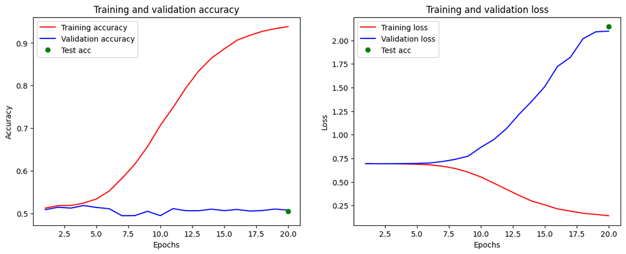

```python
plot_training_history(history_03, test_ev_03)
```

We observed an upward line for the traning accuracy which indicates that the model is learning well from the training data. However, the validation accuracy stayed same, so even if the model is learning from the data but it isn't generalizing well to the validation data. Also test accuracy is around 0.5 further demonstrates that the model's ability to generalize to unseen data is poor.

Training loss is decreasing over the epochs which is consistent with the increaing trainig accuracy. However, the fact that validation loss increases and test loss is similarly high also shows the model's failure to perform on new data. These trends suggests, the model is likely overfitting.

```python
pred_predictions3 = model_03.predict(x_pred_03)
pred_labels_array = np.array(pred_labels)
print(pred_labels_array)


predicted_classes3 = [1 if prob[0] >= 0.5 else 0 for prob in pred_predictions3]
predicted_classes3_array = np.array(predicted_classes3)
print(predicted_classes3_array)
```

```
1/1 ━━━━━━━━━━━━━━━━━━━━ 0s 105ms/step
[1 1 1 1 1 1 1 1 1 1 0 0 0 0 0 0 0 0 0 0]
[1 1 0 1 0 1 1 0 1 1 0 0 1 0 1 0 1 0 1 1]
```

The model shows the ability to correctly predict samples from both classes, but it also exhibits some inconsistency.

**Classification report Model 3**

```python
evaluate_classification(pred_labels, predicted_classes3) #results3 =
```

```
Accuracy: 0.6000
Macro-F1 Score: 0.5960
Detailed Classification Report:
              precision    recall  f1-score   support

           0       0.62      0.50      0.56        10
           1       0.58      0.70      0.64        10

    accuracy                           0.60        20
   macro avg       0.60      0.60      0.60        20
weighted avg       0.60      0.60      0.60        20
```

```
{'accuracy': 0.6,
 'macro_f1': 0.595959595959596,
 'classification_report': '              precision    recall  f1-score   support\n\n           0       0.62      0.50      0.56        10\n           1       0.58      0.70      0.64        10\n\n    accuracy                           0.60        20\n   macro avg       0.60      0.60      0.60      …
```

**Confusion** **matrix** **Model 3**

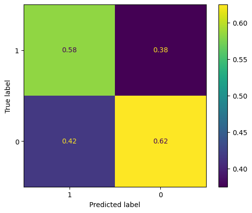

```python
#Create confusion matrix and normalizes it over predicted (columns)
result3 = confusion_matrix(pred_labels_array, predicted_classes3_array , normalize='pred', labels=[1,0] )

# visualize confusion matrix with sklearn metrics
# define matrix and create labels
result_display3 = metrics.ConfusionMatrixDisplay(confusion_matrix = result3, display_labels = ["1", "0"])

# display matrix
result_display3.plot()
plt.show()
```

Confusion matrix:

e.g: >

[TP, FP]

[FN, TN]

The Model 3 ;

This model is a somewhat balanced.

# Final evaluation

[figure not shown]

```python
# with gpt
plt.clf()

fig = plt.figure(figsize=(9, 4)) #figsize=(10, 6)
#Plot the Confusion Matrix for GPT-2
sp1 = plt.subplot(1, 4, 1)
result_display.plot(ax=sp1)
plt.gca().images[-1].colorbar.remove()
plt.title("GPT-2")

#Plot the Confusion Matrix for Model 1
sp1 = plt.subplot(1, 4, 2)
result_display1.plot(ax=sp1)
plt.gca().images[-1].colorbar.remove()
plt.title("Model 1")

#Plot the Confusion Matrix for Model 2
sp2 = plt.subplot(1, 4, 3)
result_display2.plot(ax=sp2)
plt.gca().images[-1].colorbar.remove()
plt.title("Model 2")

#Plot the Confusion Matrix for Model 3
sp3 = plt.subplot(1, 4, 4)
result_display3.plot(ax=sp3)
plt.gca().images[-1].colorbar.remove()
plt.title("Model 3")

plt.show()
```

!!! It is important to note that, as is generally accepted, the task of identifying negation in texts is challenging for deep learning models. These models often struggle to capture linguistic cues, as negation can significantly alter the overall meaning of a sentence.

To improve these models, we might consider using more sophisticated techniques or maybe chossing a different dataset since our dataset also includes some sentences/words that are hard to comprehend, even without negation. These improvements can be implemented to better handle negations. !!!

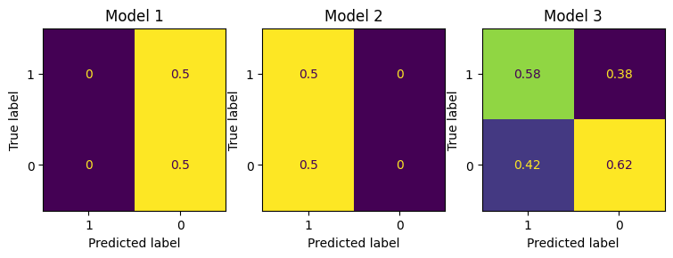

```python
#without gpt
plt.clf()

fig = plt.figure(figsize=(9, 4)) #figsize=(10, 6)

sp1 = plt.subplot(1, 3, 1)
result_display1.plot(ax=sp1) #, colorbar=False
plt.gca().images[-1].colorbar.remove()
plt.title("Model 1")


sp2 = plt.subplot(1, 3, 2)
result_display2.plot(ax=sp2)
plt.gca().images[-1].colorbar.remove()
plt.title("Model 2")


sp3 = plt.subplot(1, 3, 3)
result_display3.plot(ax=sp3)
plt.gca().images[-1].colorbar.remove()
plt.title("Model 3")

plt.show()
```

**Table with all the predictions:**

```python
table_df = {
    " ": [i for i in range(20)],
    "Premise": dataset.loc[[i for i in pred_rows], "premise"],
    "Hypothesis": dataset.loc[[i for i in pred_rows], "hypothesis"],
    "Actual Labels": dataset.loc[[i for i in pred_rows], "label"],
    "Predicted Labels Model 1": predicted_classes1,
    "Predicted Labels Model 2": predicted_classes2,
    "Predicted Labels Model 3": predicted_classes3,
    "Predicted Labels GPT": gpt_pred
}

df = pd.DataFrame(table_df).reset_index(drop=True)

def highlighter(cell_value):
    if cell_value < 5:
        return 'background-color: plum'
    elif cell_value < 10:
        return 'background-color: lightblue'
    elif cell_value < 20:
        return 'background-color: lightgreen'
    else:
        return ''

pretty_df = df.style.applymap(highlighter, subset=[" "]).hide(axis="index")
display(pretty_df)
```

|  | Premise | Hypothesis | Actual Labels | Predicted Labels Model 1 | Predicted Labels Model 2 | Predicted Labels Model 3 | Predicted Labels GPT |
| --- | --- | --- | --- | --- | --- | --- | --- |
| 0 | That's a good idea. | That's an evil idea. | 1 | 0 | 1 | 1 | 1 |
| 1 | There's something that's not right. | There's something that's not incorrect. | 1 | 0 | 1 | 1 | 1 |
| 2 | He would die before this work was complete. | He would die after this work was complete. | 1 | 0 | 1 | 0 | 1 |
| 3 | It has a high gable roof and marble end chimneys. | It has a low gable roof and brick end chimneys. | 1 | 0 | 1 | 1 | 1 |
| 4 | She often uses deliberately unrealistic characters in her work such as simplified archetypes. | She never make use of deliberately unrealistic characters in her work such as simplified archetypes. | 1 | 0 | 1 | 0 | 1 |
| 5 | She didn't leave. | She left. | 1 | 0 | 1 | 1 | 1 |
| 6 | Its foundations are not Gravel Point, Charlevoix Limestone, Petoskey, and Whiskey Creek. | Its formations are Gravel Point, Charlevoix Limestone, Petoskey, and Whiskey Creek. | 1 | 0 | 1 | 1 | 1 |
| 7 | Looks good in the picture, but this case wasn't a huge disappointment!! | Looks good in the picture, but this case was a huge disappointment!! | 1 | 0 | 1 | 0 | 1 |
| 8 | It doesn't work great with a car charger, especially if you cannot plug in two adapters at the same time. | It works great with a car charger, especially if you cannot plug in two adapters at the same time. | 1 | 0 | 1 | 1 | 1 |
| 9 | External corrosion was not suspected at all. | External corrosion was suspected. | 1 | 0 | 1 | 1 | 1 |
| 10 | They are followed by small oval fruit. | They are followed by some fruit. | 0 | 0 | 1 | 0 | 1 |
| 11 | No, it's the same thing. | No, it's not a different thing. | 0 | 0 | 1 | 0 | 1 |
| 12 | I'm not a good talker either. | I'm a bad talker too. | 0 | 0 | 1 | 1 | 1 |
| 13 | Grisham was close to winning the popular vote. | Grisham almost won the popular vote. | 0 | 0 | 1 | 0 | 1 |
| 14 | Their menu is reasonably priced. | Their menu is diverse, and reasonably priced. | 0 | 0 | 1 | 1 | 1 |
| 15 | Shetty was elected to the Karnataka Legislative Assembly in 1967 from the Puttur constituency. | He was elected to the Legislative Assembly from the Puttur constituency. | 0 | 0 | 1 | 0 | 1 |
| 16 | HMAC_DRBG also has a machine-verified security proof. | HMAC_DRBG has a machine-verified security proof. | 0 | 0 | 1 | 1 | 1 |
| 17 | The contract to buy Solel Solar Systems was signed in October of 2009. | In October 2009, Siemens signed a $418-million contract to buy Solel Solar Systems. | 0 | 0 | 1 | 0 | 1 |
| 18 | The analysis device's wiring is used as a mystical conduit. | The wiring in the analysis device is simply used as a mystical conduit. | 0 | 0 | 1 | 1 | 1 |
| 19 | The pleather case doesn't fit. | The case doesn't fit. | 0 | 0 | 1 | 1 | 1 |

# Sources

@misc{anschütz2023correct, title={This is not correct! Negation-aware Evaluation of Language Generation Systems}, author={Miriam Anschütz and Diego Miguel Lozano and Georg Groh}, year={2023}, eprint={2307.13989}, archivePrefix={arXiv}, primaryClass={cs.CL} }

We inspired from: https://keras.io/examples/nlp/semantic_similarity_with_keras_nlp/